# Motor Trend - Analysis

Sath_MS

08/08/2020

## Summary

At Motor Trend magazine, we are interested in looking at a collection of cars and interested in exploring relationship between miles per gallon(mpg) and rest of the variables.

In particular, we are interested in two questions: – Is an automatic or manual transmission better for MPG? – Quantify the mpg difference between automatic and manual transmissions.

## Exploratory Analysis

Lets do some preliminary analysis by plotting a correlation matrix.

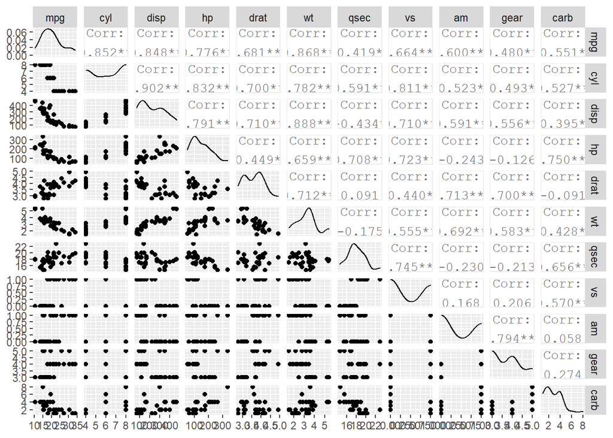

```r
library(ggplot2)
library(GGally)
ggpairs(mtcars)
```

It appears there are a few variables displaying good correlation with mpg. So we can try constructing linear models to predict mpg.

## Linear Modelling.

First, we build a model with all the variables.

```r
model_all <- lm(mpg ~., data = mtcars)
summary(model_all)
```

```
##
## Call:
## lm(formula = mpg ~ ., data = mtcars)
##
## Residuals:
##     Min      1Q  Median      3Q     Max
## -3.4506 -1.6044 -0.1196  1.2193  4.6271
##
## Coefficients:
##             Estimate Std. Error t value Pr(>|t|)
## (Intercept) 12.30337   18.71788   0.657   0.5181
## cyl         -0.11144    1.04502  -0.107   0.9161
## disp         0.01334    0.01786   0.747   0.4635
## hp          -0.02148    0.02177  -0.987   0.3350
## drat         0.78711    1.63537   0.481   0.6353
## wt          -3.71530    1.89441  -1.961   0.0633 .
## qsec         0.82104    0.73084   1.123   0.2739
## vs           0.31776    2.10451   0.151   0.8814
## am           2.52023    2.05665   1.225   0.2340
## gear         0.65541    1.49326   0.439   0.6652
## carb        -0.19942    0.82875  -0.241   0.8122
## ---
## Signif. codes:  0 '***' 0.001 '**' 0.01 '*' 0.05 '.' 0.1 ' ' 1
##
## Residual standard error: 2.65 on 21 degrees of freedom
## Multiple R-squared:  0.869,  Adjusted R-squared:  0.8066
## F-statistic: 13.93 on 10 and 21 DF,  p-value: 3.793e-07
```

In the model (model_all), not all coefficients are significant, yet adjusted R Squared is high (0.806). We probably are overfitting with multicollinearity.

## Is an automatic or manual transmission better for MPG?

Now, to our object of our analysis to answer the question that is which is better for MPG, automatic or manual transmission?

Here we build a model with only transmission(am) as the predictor variable.

```r
model_am <- lm(mpg ~ am, data = mtcars)
summary(model_am)
```

```
##
## Call:
## lm(formula = mpg ~ am, data = mtcars)
##
## Residuals:
##     Min      1Q  Median      3Q     Max
## -9.3923 -3.0923 -0.2974  3.2439  9.5077
##
## Coefficients:
##             Estimate Std. Error t value Pr(>|t|)
## (Intercept)   17.147      1.125  15.247 1.13e-15 ***
## am             7.245      1.764   4.106 0.000285 ***
## ---
## Signif. codes:  0 '***' 0.001 '**' 0.01 '*' 0.05 '.' 0.1 ' ' 1
##
## Residual standard error: 4.902 on 30 degrees of freedom
## Multiple R-squared:  0.3598, Adjusted R-squared:  0.3385
## F-statistic: 16.86 on 1 and 30 DF,  p-value: 0.000285
```

In the transmission model (model_am), coefficient is significant from zero (i.e 7.24 mpg higher for manual than automatic), however the adjusted R squared is small (0.34) indicating that a transmission model has only a small explanatory power over mpg.

## Model Stepwise selection

Now, lets see if we can fit a better model than the prior models. Lets choose a model by AIC in a stepwise algorithm.

```r
#bestFit <- step(model_all, direction = "both", trace = TRUE)
bestFit <- step(model_all, direction = "both", trace = FALSE)
summary(bestFit)
```

```
##
## Call:
## lm(formula = mpg ~ wt + qsec + am, data = mtcars)
##
## Residuals:
##     Min      1Q  Median      3Q     Max
## -3.4811 -1.5555 -0.7257  1.4110  4.6610
##
## Coefficients:
##             Estimate Std. Error t value Pr(>|t|)
## (Intercept)   9.6178     6.9596   1.382 0.177915
## wt           -3.9165     0.7112  -5.507 6.95e-06 ***
## qsec          1.2259     0.2887   4.247 0.000216 ***
## am            2.9358     1.4109   2.081 0.046716 *
## ---
## Signif. codes:  0 '***' 0.001 '**' 0.01 '*' 0.05 '.' 0.1 ' ' 1
##
## Residual standard error: 2.459 on 28 degrees of freedom
## Multiple R-squared:  0.8497, Adjusted R-squared:  0.8336
## F-statistic: 52.75 on 3 and 28 DF,  p-value: 1.21e-11
```

In the ‘bestFit’ model mpg ~ wt + qsec + am, we see an R squared of 0.85.Also, we could conclude that (with a p < 0.05 confidence) cars with manual transmission have 2.9358 (say 3) more miles per gallon than automatic transmissions.

## Residual Dignostics

Lets check if the residuals from our bestFit model are normally distributed using Shapiro-wilkins test (i.e if p > 0.05)

```r
shapiro.test(bestFit$res)
```

```
##
##  Shapiro-Wilk normality test
##
## data:  bestFit$res
## W = 0.9411, p-value = 0.08043
```

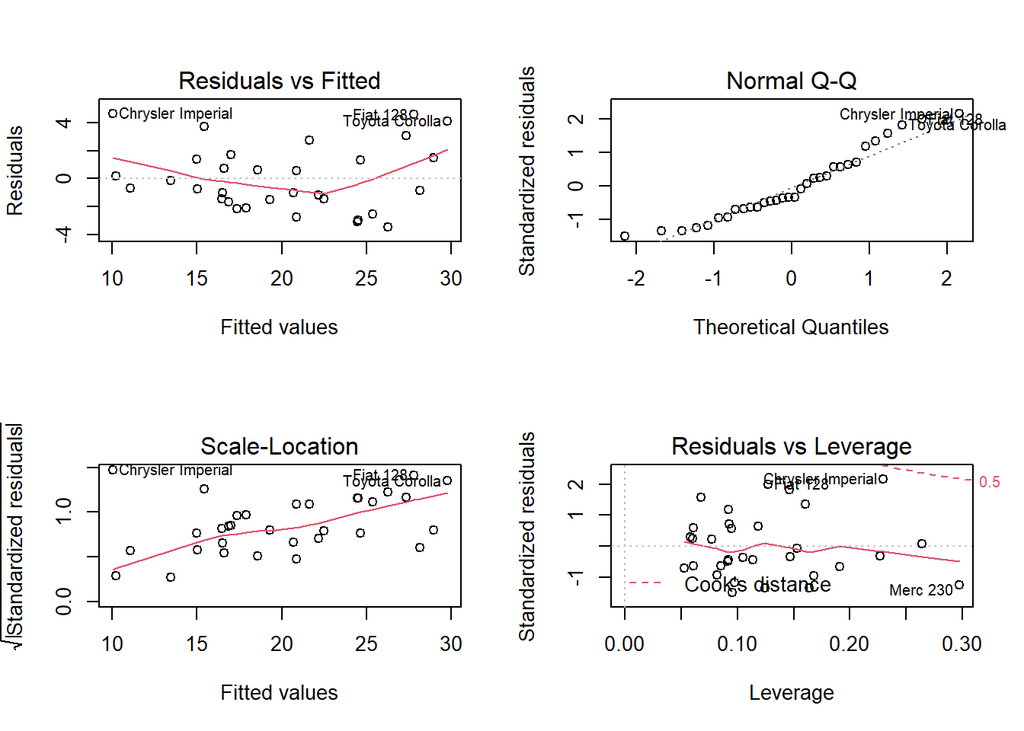

```r
par(mfrow=c(2,2))
plot(bestFit)
```

In the normal Q-Q (quantile vs quantile) plot:

A straight line on the QQ Plot tells us we have a normal distribution. The uniform distribution has too many observations in both extremities (very high and very low values). The exponential distribution has too many observations on the lower values, but too little in the higher values

We can conclude that residuals in our bestfit model is normally distributed.

```r
#signif(cooks.distance(bestFit),2)
ls.diag(bestFit)
```

[output not shown]

[output cut: 16 more lines]

[output not shown]

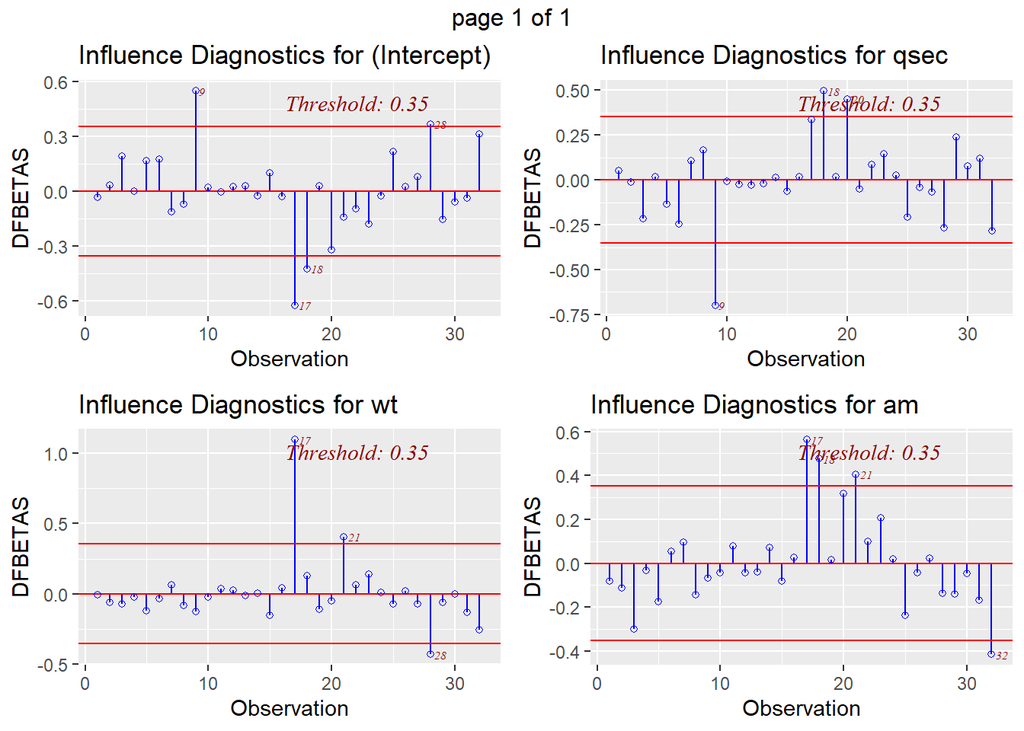

```r
library(olsrr)
# Influence
ols_plot_dfbetas(bestFit)
```

In general, large values of DFBETAS indicate observations that are influential in estimating a given parameter.

References: https://cran.r-project.org/web/packages/olsrr/vignettes/influence_measures.html

## Conclusions

1. Holding all other paramters constant, manual transmission will increase your MPG.
2. Based on the ‘bestFit’ model, we could conclude with a p < 0.05 confidence, cars with manual transmission have approx 3 more miles per gallon than automatic transmissions.